# Risk Factor Analysis

## Outcome Variable

**Outcome Variable:** ever_wasted

## Predictor Variables

**Intervention Variable:** parity

**Adjustment Set:**

- arm
- W_mage
- meducyrs
- feducyrs
- hhwealth_quart
- W_mhtcm
- vagbrth
- W_nrooms
- impfloor
- impsan
- safeh20
- delta_W_mage
- delta_meducyrs
- delta_feducyrs
- delta_hhwealth_quart
- delta_W_mhtcm
- delta_vagbrth
- delta_W_nrooms
- delta_impfloor
- delta_impsan
- delta_safeh20

## Stratifying Variables

The analysis was stratified on these variable(s):

- agecat
- studyid
- country

## Data Summary

| agecat | studyid | country | parity | ever_wasted | n_cell | n |
| --- | --- | --- | --- | --- | --- | --- |
| 0-24 months | ki1000304b-SAS-CompFeed | INDIA | 1 | 0 | 273 | 1513 |
| 0-24 months | ki1000304b-SAS-CompFeed | INDIA | 1 | 1 | 175 | 1513 |
| 0-24 months | ki1000304b-SAS-CompFeed | INDIA | 2 | 0 | 219 | 1513 |
| 0-24 months | ki1000304b-SAS-CompFeed | INDIA | 2 | 1 | 135 | 1513 |
| 0-24 months | ki1000304b-SAS-CompFeed | INDIA | 3+ | 0 | 393 | 1513 |
| 0-24 months | ki1000304b-SAS-CompFeed | INDIA | 3+ | 1 | 318 | 1513 |
| 0-24 months | ki1000304b-SAS-FoodSuppl | INDIA | 1 | 0 | 51 | 397 |
| 0-24 months | ki1000304b-SAS-FoodSuppl | INDIA | 1 | 1 | 26 | 397 |
| 0-24 months | ki1000304b-SAS-FoodSuppl | INDIA | 2 | 0 | 46 | 397 |
| 0-24 months | ki1000304b-SAS-FoodSuppl | INDIA | 2 | 1 | 46 | 397 |
| 0-24 months | ki1000304b-SAS-FoodSuppl | INDIA | 3+ | 0 | 112 | 397 |
| 0-24 months | ki1000304b-SAS-FoodSuppl | INDIA | 3+ | 1 | 116 | 397 |
| 0-24 months | ki1017093b-PROVIDE | BANGLADESH | 1 | 0 | 163 | 700 |
| 0-24 months | ki1017093b-PROVIDE | BANGLADESH | 1 | 1 | 108 | 700 |
| 0-24 months | ki1017093b-PROVIDE | BANGLADESH | 2 | 0 | 170 | 700 |
| 0-24 months | ki1017093b-PROVIDE | BANGLADESH | 2 | 1 | 74 | 700 |
| 0-24 months | ki1017093b-PROVIDE | BANGLADESH | 3+ | 0 | 121 | 700 |
| 0-24 months | ki1017093b-PROVIDE | BANGLADESH | 3+ | 1 | 64 | 700 |
| 0-24 months | ki1066203-TanzaniaChild2 | TANZANIA, UNITED REPUBLIC OF | 1 | 0 | 624 | 2357 |
| 0-24 months | ki1066203-TanzaniaChild2 | TANZANIA, UNITED REPUBLIC OF | 1 | 1 | 197 | 2357 |
| 0-24 months | ki1066203-TanzaniaChild2 | TANZANIA, UNITED REPUBLIC OF | 2 | 0 | 583 | 2357 |
| 0-24 months | ki1066203-TanzaniaChild2 | TANZANIA, UNITED REPUBLIC OF | 2 | 1 | 188 | 2357 |
| 0-24 months | ki1066203-TanzaniaChild2 | TANZANIA, UNITED REPUBLIC OF | 3+ | 0 | 592 | 2357 |
| 0-24 months | ki1066203-TanzaniaChild2 | TANZANIA, UNITED REPUBLIC OF | 3+ | 1 | 173 | 2357 |
| 0-24 months | ki1101329-Keneba | GAMBIA | 1 | 0 | 160 | 1989 |
| 0-24 months | ki1101329-Keneba | GAMBIA | 1 | 1 | 80 | 1989 |
| 0-24 months | ki1101329-Keneba | GAMBIA | 2 | 0 | 138 | 1989 |
| 0-24 months | ki1101329-Keneba | GAMBIA | 2 | 1 | 76 | 1989 |
| 0-24 months | ki1101329-Keneba | GAMBIA | 3+ | 0 | 887 | 1989 |
| 0-24 months | ki1101329-Keneba | GAMBIA | 3+ | 1 | 648 | 1989 |

[output cut: 168 more lines]

The following strata were considered:

- agecat: 0-24 months, studyid: ki1000304b-SAS-CompFeed, country: INDIA
- agecat: 0-24 months, studyid: ki1000304b-SAS-FoodSuppl, country: INDIA
- agecat: 0-24 months, studyid: ki1017093b-PROVIDE, country: BANGLADESH
- agecat: 0-24 months, studyid: ki1066203-TanzaniaChild2, country: TANZANIA, UNITED REPUBLIC OF
- agecat: 0-24 months, studyid: ki1101329-Keneba, country: GAMBIA
- agecat: 0-24 months, studyid: ki1113344-GMS-Nepal, country: NEPAL
- agecat: 0-24 months, studyid: ki1126311-ZVITAMBO, country: ZIMBABWE
- agecat: 0-24 months, studyid: ki1135781-COHORTS, country: GUATEMALA
- agecat: 0-24 months, studyid: ki1135781-COHORTS, country: INDIA
- agecat: 0-24 months, studyid: ki1135781-COHORTS, country: PHILIPPINES
- agecat: 0-24 months, studyid: kiGH5241-JiVitA-3, country: BANGLADESH
- agecat: 0-6 months, studyid: ki1000304b-SAS-CompFeed, country: INDIA
- agecat: 0-6 months, studyid: ki1000304b-SAS-FoodSuppl, country: INDIA
- agecat: 0-6 months, studyid: ki1017093b-PROVIDE, country: BANGLADESH
- agecat: 0-6 months, studyid: ki1066203-TanzaniaChild2, country: TANZANIA, UNITED REPUBLIC OF
- agecat: 0-6 months, studyid: ki1101329-Keneba, country: GAMBIA
- agecat: 0-6 months, studyid: ki1113344-GMS-Nepal, country: NEPAL
- agecat: 0-6 months, studyid: ki1126311-ZVITAMBO, country: ZIMBABWE
- agecat: 0-6 months, studyid: ki1135781-COHORTS, country: GUATEMALA
- agecat: 0-6 months, studyid: ki1135781-COHORTS, country: INDIA
- agecat: 0-6 months, studyid: ki1135781-COHORTS, country: PHILIPPINES
- agecat: 0-6 months, studyid: kiGH5241-JiVitA-3, country: BANGLADESH
- agecat: 6-24 months, studyid: ki1000304b-SAS-CompFeed, country: INDIA
- agecat: 6-24 months, studyid: ki1000304b-SAS-FoodSuppl, country: INDIA
- agecat: 6-24 months, studyid: ki1017093b-PROVIDE, country: BANGLADESH
- agecat: 6-24 months, studyid: ki1066203-TanzaniaChild2, country: TANZANIA, UNITED REPUBLIC OF
- agecat: 6-24 months, studyid: ki1101329-Keneba, country: GAMBIA
- agecat: 6-24 months, studyid: ki1113344-GMS-Nepal, country: NEPAL
- agecat: 6-24 months, studyid: ki1126311-ZVITAMBO, country: ZIMBABWE
- agecat: 6-24 months, studyid: ki1135781-COHORTS, country: GUATEMALA
- agecat: 6-24 months, studyid: ki1135781-COHORTS, country: INDIA
- agecat: 6-24 months, studyid: ki1135781-COHORTS, country: PHILIPPINES
- agecat: 6-24 months, studyid: kiGH5241-JiVitA-3, country: BANGLADESH

## Methods Detail

We’re interested in the causal parameters $E[Y_a]$ for all values of $a \in \mathcal{A}$. These parameters represent the mean outcome if, possibly contrary to fact, we intervened to set all units to have $A=a$. Under the randomization and positivity assumptions, these are identified by the statistical parameters $\psi_a=E_W[E_{Y|A,W}(Y|A=a,W)]$. In addition, we’re interested in the mean of $Y$, $E[Y]$ under no intervention (the observed mean). We will estimate these parameters by using SuperLearner to fit the relevant likelihood factors – $E_{Y|A,W}(Y|A=a,W)$ and $p(A=a|W)$, and then updating our likelihood fit using a joint TMLE.

For unadjusted analyses ($W=\{\}$), initial likelihoods were estimated using Lrnr_glm to estimate the simple $E(Y|A)$ and Lrnr_mean to estimate $p(A)$. For adjusted analyses, a small library containing Lrnr_glmnet, Lrnr_xgboost, and Lrnr_mean was used.

Having estimated these parameters, we will then use the delta method to estimate relative risks and attributable risks relative to a prespecified baseline level of $A$.

# Results Detail

## Results Plots

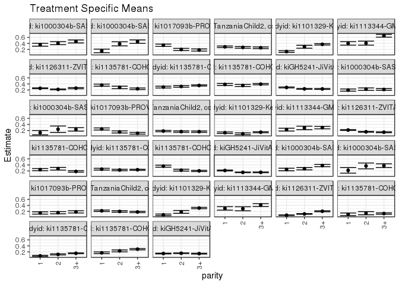

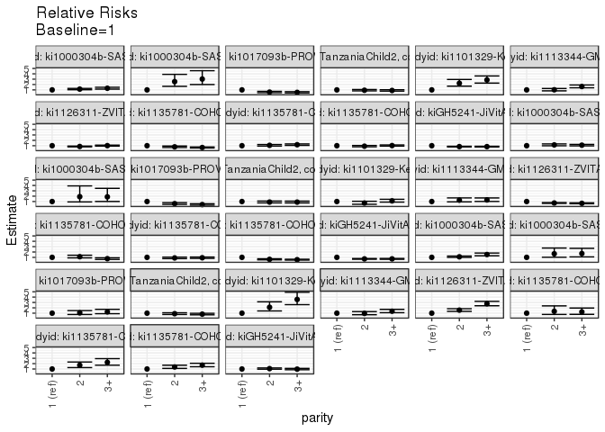

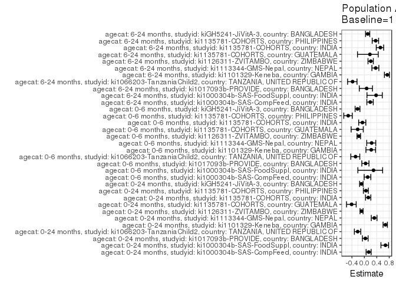

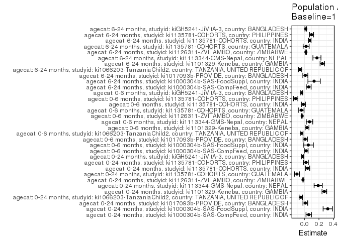

## Results Table

### Parameter: TSM

| agecat | studyid | country | intervention_level | baseline_level | estimate | ci_lower | ci_upper |
| --- | --- | --- | --- | --- | --- | --- | --- |
| 0-24 months | ki1000304b-SAS-CompFeed | INDIA | 1 | NA | 0.3566042 | 0.3094379 | 0.4037704 |
| 0-24 months | ki1000304b-SAS-CompFeed | INDIA | 2 | NA | 0.4081894 | 0.3577194 | 0.4586594 |
| 0-24 months | ki1000304b-SAS-CompFeed | INDIA | 3+ | NA | 0.4650087 | 0.4158878 | 0.5141297 |
| 0-24 months | ki1000304b-SAS-FoodSuppl | INDIA | 1 | NA | 0.1520441 | 0.0921622 | 0.2119260 |
| 0-24 months | ki1000304b-SAS-FoodSuppl | INDIA | 2 | NA | 0.3868639 | 0.3194044 | 0.4543235 |
| 0-24 months | ki1000304b-SAS-FoodSuppl | INDIA | 3+ | NA | 0.4594815 | 0.4032719 | 0.5156911 |
| 0-24 months | ki1017093b-PROVIDE | BANGLADESH | 1 | NA | 0.3398879 | 0.3024639 | 0.3773118 |
| 0-24 months | ki1017093b-PROVIDE | BANGLADESH | 2 | NA | 0.1990023 | 0.1616083 | 0.2363963 |
| 0-24 months | ki1017093b-PROVIDE | BANGLADESH | 3+ | NA | 0.1817915 | 0.1458702 | 0.2177128 |
| 0-24 months | ki1066203-TanzaniaChild2 | TANZANIA, UNITED REPUBLIC OF | 1 | NA | 0.2874754 | 0.2601865 | 0.3147642 |
| 0-24 months | ki1066203-TanzaniaChild2 | TANZANIA, UNITED REPUBLIC OF | 2 | NA | 0.2684224 | 0.2404864 | 0.2963584 |
| 0-24 months | ki1066203-TanzaniaChild2 | TANZANIA, UNITED REPUBLIC OF | 3+ | NA | 0.2566232 | 0.2300092 | 0.2832372 |
| 0-24 months | ki1101329-Keneba | GAMBIA | 1 | NA | 0.1296236 | 0.1010534 | 0.1581937 |
| 0-24 months | ki1101329-Keneba | GAMBIA | 2 | NA | 0.2896398 | 0.2409486 | 0.3383310 |
| 0-24 months | ki1101329-Keneba | GAMBIA | 3+ | NA | 0.3701403 | 0.3466249 | 0.3936558 |
| 0-24 months | ki1113344-GMS-Nepal | NEPAL | 1 | NA | 0.4018415 | 0.3435236 | 0.4601595 |
| 0-24 months | ki1113344-GMS-Nepal | NEPAL | 2 | NA | 0.4091851 | 0.3427080 | 0.4756622 |
| 0-24 months | ki1113344-GMS-Nepal | NEPAL | 3+ | NA | 0.6541805 | 0.6092084 | 0.6991525 |
| 0-24 months | ki1126311-ZVITAMBO | ZIMBABWE | 1 | NA | 0.2556823 | 0.2426273 | 0.2687373 |
| 0-24 months | ki1126311-ZVITAMBO | ZIMBABWE | 2 | NA | 0.2183346 | 0.2042612 | 0.2324081 |
| 0-24 months | ki1126311-ZVITAMBO | ZIMBABWE | 3+ | NA | 0.2592559 | 0.2398258 | 0.2786861 |
| 0-24 months | ki1135781-COHORTS | GUATEMALA | 1 | NA | 0.3595819 | 0.3251643 | 0.3939994 |
| 0-24 months | ki1135781-COHORTS | GUATEMALA | 2 | NA | 0.2835606 | 0.2419952 | 0.3251260 |
| 0-24 months | ki1135781-COHORTS | GUATEMALA | 3+ | NA | 0.2384317 | 0.2130964 | 0.2637670 |
| 0-24 months | ki1135781-COHORTS | INDIA | 1 | NA | 0.2947394 | 0.2643765 | 0.3251022 |
| 0-24 months | ki1135781-COHORTS | INDIA | 2 | NA | 0.3157743 | 0.2893585 | 0.3421902 |
| 0-24 months | ki1135781-COHORTS | INDIA | 3+ | NA | 0.3487255 | 0.3302372 | 0.3672137 |
| 0-24 months | ki1135781-COHORTS | PHILIPPINES | 1 | NA | 0.3829901 | 0.3487615 | 0.4172187 |
| 0-24 months | ki1135781-COHORTS | PHILIPPINES | 2 | NA | 0.3485572 | 0.3150268 | 0.3820876 |
| 0-24 months | ki1135781-COHORTS | PHILIPPINES | 3+ | NA | 0.3923251 | 0.3689098 | 0.4157403 |

[output cut: 69 more lines]

### Parameter: E(Y)

| agecat | studyid | country | intervention_level | baseline_level | estimate | ci_lower | ci_upper |
| --- | --- | --- | --- | --- | --- | --- | --- |
| 0-24 months | ki1000304b-SAS-CompFeed | INDIA | NA | NA | 0.4150694 | 0.3581204 | 0.4720184 |
| 0-24 months | ki1000304b-SAS-FoodSuppl | INDIA | NA | NA | 0.4735516 | 0.4243746 | 0.5227286 |
| 0-24 months | ki1017093b-PROVIDE | BANGLADESH | NA | NA | 0.3514286 | 0.3160364 | 0.3868207 |
| 0-24 months | ki1066203-TanzaniaChild2 | TANZANIA, UNITED REPUBLIC OF | NA | NA | 0.2367416 | 0.2195770 | 0.2539062 |
| 0-24 months | ki1101329-Keneba | GAMBIA | NA | NA | 0.4042232 | 0.3826511 | 0.4257953 |
| 0-24 months | ki1113344-GMS-Nepal | NEPAL | NA | NA | 0.5913621 | 0.5520608 | 0.6306634 |
| 0-24 months | ki1126311-ZVITAMBO | ZIMBABWE | NA | NA | 0.2347539 | 0.2277172 | 0.2417906 |
| 0-24 months | ki1135781-COHORTS | GUATEMALA | NA | NA | 0.2550336 | 0.2316956 | 0.2783715 |
| 0-24 months | ki1135781-COHORTS | INDIA | NA | NA | 0.3378028 | 0.3241691 | 0.3514364 |
| 0-24 months | ki1135781-COHORTS | PHILIPPINES | NA | NA | 0.4036125 | 0.3861835 | 0.4210415 |
| 0-24 months | kiGH5241-JiVitA-3 | BANGLADESH | NA | NA | 0.2581952 | 0.2517314 | 0.2646590 |
| 0-6 months | ki1000304b-SAS-CompFeed | INDIA | NA | NA | 0.2199336 | 0.1753445 | 0.2645227 |
| 0-6 months | ki1000304b-SAS-FoodSuppl | INDIA | NA | NA | 0.1788413 | 0.1410973 | 0.2165853 |
| 0-6 months | ki1017093b-PROVIDE | BANGLADESH | NA | NA | 0.2585714 | 0.2261125 | 0.2910304 |
| 0-6 months | ki1066203-TanzaniaChild2 | TANZANIA, UNITED REPUBLIC OF | NA | NA | 0.1395842 | 0.1255905 | 0.1535779 |
| 0-6 months | ki1101329-Keneba | GAMBIA | NA | NA | 0.1613611 | 0.1444653 | 0.1782570 |
| 0-6 months | ki1113344-GMS-Nepal | NEPAL | NA | NA | 0.2956811 | 0.2591967 | 0.3321655 |
| 0-6 months | ki1126311-ZVITAMBO | ZIMBABWE | NA | NA | 0.1810631 | 0.1746489 | 0.1874773 |
| 0-6 months | ki1135781-COHORTS | GUATEMALA | NA | NA | 0.2003763 | 0.1763021 | 0.2244505 |
| 0-6 months | ki1135781-COHORTS | INDIA | NA | NA | 0.2434743 | 0.2308547 | 0.2560940 |
| 0-6 months | ki1135781-COHORTS | PHILIPPINES | NA | NA | 0.2355453 | 0.2204685 | 0.2506222 |
| 0-6 months | kiGH5241-JiVitA-3 | BANGLADESH | NA | NA | 0.1762799 | 0.1706566 | 0.1819032 |
| 6-24 months | ki1000304b-SAS-CompFeed | INDIA | NA | NA | 0.3059755 | 0.2638053 | 0.3481458 |
| 6-24 months | ki1000304b-SAS-FoodSuppl | INDIA | NA | NA | 0.3518987 | 0.3047435 | 0.3990540 |
| 6-24 months | ki1017093b-PROVIDE | BANGLADESH | NA | NA | 0.1609756 | 0.1319065 | 0.1900447 |
| 6-24 months | ki1066203-TanzaniaChild2 | TANZANIA, UNITED REPUBLIC OF | NA | NA | 0.1600403 | 0.1439152 | 0.1761654 |
| 6-24 months | ki1101329-Keneba | GAMBIA | NA | NA | 0.3341996 | 0.3131165 | 0.3552826 |
| 6-24 months | ki1113344-GMS-Nepal | NEPAL | NA | NA | 0.4728814 | 0.4325613 | 0.5132014 |
| 6-24 months | ki1126311-ZVITAMBO | ZIMBABWE | NA | NA | 0.0939867 | 0.0884555 | 0.0995179 |
| 6-24 months | ki1135781-COHORTS | GUATEMALA | NA | NA | 0.1269580 | 0.1082147 | 0.1457012 |
| 6-24 months | ki1135781-COHORTS | INDIA | NA | NA | 0.1419682 | 0.1315821 | 0.1523542 |
| 6-24 months | ki1135781-COHORTS | PHILIPPINES | NA | NA | 0.2666429 | 0.2502871 | 0.2829988 |
| 6-24 months | kiGH5241-JiVitA-3 | BANGLADESH | NA | NA | 0.1639050 | 0.1577770 | 0.1700330 |

### Parameter: RR

| agecat | studyid | country | intervention_level | baseline_level | estimate | ci_lower | ci_upper |
| --- | --- | --- | --- | --- | --- | --- | --- |
| 0-24 months | ki1000304b-SAS-CompFeed | INDIA | 1 | 1 | 1.0000000 | 1.0000000 | 1.0000000 |
| 0-24 months | ki1000304b-SAS-CompFeed | INDIA | 2 | 1 | 1.1446569 | 1.0251247 | 1.2781268 |
| 0-24 months | ki1000304b-SAS-CompFeed | INDIA | 3+ | 1 | 1.3039913 | 1.1445443 | 1.4856509 |
| 0-24 months | ki1000304b-SAS-FoodSuppl | INDIA | 1 | 1 | 1.0000000 | 1.0000000 | 1.0000000 |
| 0-24 months | ki1000304b-SAS-FoodSuppl | INDIA | 2 | 1 | 2.5444191 | 1.6608162 | 3.8981246 |
| 0-24 months | ki1000304b-SAS-FoodSuppl | INDIA | 3+ | 1 | 3.0220276 | 1.9955801 | 4.5764391 |
| 0-24 months | ki1017093b-PROVIDE | BANGLADESH | 1 | 1 | 1.0000000 | 1.0000000 | 1.0000000 |
| 0-24 months | ki1017093b-PROVIDE | BANGLADESH | 2 | 1 | 0.5854939 | 0.4713591 | 0.7272653 |
| 0-24 months | ki1017093b-PROVIDE | BANGLADESH | 3+ | 1 | 0.5348573 | 0.4256245 | 0.6721237 |
| 0-24 months | ki1066203-TanzaniaChild2 | TANZANIA, UNITED REPUBLIC OF | 1 | 1 | 1.0000000 | 1.0000000 | 1.0000000 |
| 0-24 months | ki1066203-TanzaniaChild2 | TANZANIA, UNITED REPUBLIC OF | 2 | 1 | 0.9337231 | 0.8118963 | 1.0738302 |
| 0-24 months | ki1066203-TanzaniaChild2 | TANZANIA, UNITED REPUBLIC OF | 3+ | 1 | 0.8926788 | 0.7756214 | 1.0274027 |
| 0-24 months | ki1101329-Keneba | GAMBIA | 1 | 1 | 1.0000000 | 1.0000000 | 1.0000000 |
| 0-24 months | ki1101329-Keneba | GAMBIA | 2 | 1 | 2.2344688 | 1.6952872 | 2.9451357 |
| 0-24 months | ki1101329-Keneba | GAMBIA | 3+ | 1 | 2.8555021 | 2.2647315 | 3.6003791 |
| 0-24 months | ki1113344-GMS-Nepal | NEPAL | 1 | 1 | 1.0000000 | 1.0000000 | 1.0000000 |
| 0-24 months | ki1113344-GMS-Nepal | NEPAL | 2 | 1 | 1.0182747 | 0.8204162 | 1.2638504 |
| 0-24 months | ki1113344-GMS-Nepal | NEPAL | 3+ | 1 | 1.6279563 | 1.3870558 | 1.9106957 |
| 0-24 months | ki1126311-ZVITAMBO | ZIMBABWE | 1 | 1 | 1.0000000 | 1.0000000 | 1.0000000 |
| 0-24 months | ki1126311-ZVITAMBO | ZIMBABWE | 2 | 1 | 0.8539295 | 0.7866316 | 0.9269848 |
| 0-24 months | ki1126311-ZVITAMBO | ZIMBABWE | 3+ | 1 | 1.0139769 | 0.9261732 | 1.1101047 |
| 0-24 months | ki1135781-COHORTS | GUATEMALA | 1 | 1 | 1.0000000 | 1.0000000 | 1.0000000 |
| 0-24 months | ki1135781-COHORTS | GUATEMALA | 2 | 1 | 0.7885843 | 0.6624013 | 0.9388043 |
| 0-24 months | ki1135781-COHORTS | GUATEMALA | 3+ | 1 | 0.6630805 | 0.5758496 | 0.7635253 |
| 0-24 months | ki1135781-COHORTS | INDIA | 1 | 1 | 1.0000000 | 1.0000000 | 1.0000000 |
| 0-24 months | ki1135781-COHORTS | INDIA | 2 | 1 | 1.0713681 | 0.9385518 | 1.2229795 |
| 0-24 months | ki1135781-COHORTS | INDIA | 3+ | 1 | 1.1831656 | 1.0540005 | 1.3281596 |
| 0-24 months | ki1135781-COHORTS | PHILIPPINES | 1 | 1 | 1.0000000 | 1.0000000 | 1.0000000 |
| 0-24 months | ki1135781-COHORTS | PHILIPPINES | 2 | 1 | 0.9100946 | 0.7982957 | 1.0375505 |
| 0-24 months | ki1135781-COHORTS | PHILIPPINES | 3+ | 1 | 1.0243739 | 0.9199633 | 1.1406346 |

[output cut: 69 more lines]

### Parameter: PAR

| agecat | studyid | country | intervention_level | baseline_level | estimate | ci_lower | ci_upper |
| --- | --- | --- | --- | --- | --- | --- | --- |
| 0-24 months | ki1000304b-SAS-CompFeed | INDIA | 1 | NA | 0.0584652 | 0.0210888 | 0.0958417 |
| 0-24 months | ki1000304b-SAS-FoodSuppl | INDIA | 1 | NA | 0.3215075 | 0.2574558 | 0.3855593 |
| 0-24 months | ki1017093b-PROVIDE | BANGLADESH | 1 | NA | 0.0115407 | -0.0211836 | 0.0442650 |
| 0-24 months | ki1066203-TanzaniaChild2 | TANZANIA, UNITED REPUBLIC OF | 1 | NA | -0.0507337 | -0.0743178 | -0.0271497 |
| 0-24 months | ki1101329-Keneba | GAMBIA | 1 | NA | 0.2745997 | 0.2424771 | 0.3067223 |
| 0-24 months | ki1113344-GMS-Nepal | NEPAL | 1 | NA | 0.1895206 | 0.1330790 | 0.2459622 |
| 0-24 months | ki1126311-ZVITAMBO | ZIMBABWE | 1 | NA | -0.0209284 | -0.0323020 | -0.0095547 |
| 0-24 months | ki1135781-COHORTS | GUATEMALA | 1 | NA | -0.1045483 | -0.1396143 | -0.0694823 |
| 0-24 months | ki1135781-COHORTS | INDIA | 1 | NA | 0.0430634 | 0.0141027 | 0.0720241 |
| 0-24 months | ki1135781-COHORTS | PHILIPPINES | 1 | NA | 0.0206224 | -0.0117225 | 0.0529673 |
| 0-24 months | kiGH5241-JiVitA-3 | BANGLADESH | 1 | NA | -0.0245523 | -0.0388819 | -0.0102227 |
| 0-6 months | ki1000304b-SAS-CompFeed | INDIA | 1 | NA | 0.0235792 | -0.0023857 | 0.0495441 |
| 0-6 months | ki1000304b-SAS-FoodSuppl | INDIA | 1 | NA | 0.0526965 | -0.0169108 | 0.1223038 |
| 0-6 months | ki1017093b-PROVIDE | BANGLADESH | 1 | NA | 0.0102843 | -0.0197011 | 0.0402697 |
| 0-6 months | ki1066203-TanzaniaChild2 | TANZANIA, UNITED REPUBLIC OF | 1 | NA | -0.0395792 | -0.0588801 | -0.0202783 |
| 0-6 months | ki1101329-Keneba | GAMBIA | 1 | NA | 0.0357891 | 0.0095780 | 0.0620002 |
| 0-6 months | ki1113344-GMS-Nepal | NEPAL | 1 | NA | 0.0694625 | 0.0244316 | 0.1144934 |
| 0-6 months | ki1126311-ZVITAMBO | ZIMBABWE | 1 | NA | -0.0321675 | -0.0423782 | -0.0219569 |
| 0-6 months | ki1135781-COHORTS | GUATEMALA | 1 | NA | -0.0430570 | -0.0798328 | -0.0062812 |
| 0-6 months | ki1135781-COHORTS | INDIA | 1 | NA | -0.0150420 | -0.0427867 | 0.0127027 |
| 0-6 months | ki1135781-COHORTS | PHILIPPINES | 1 | NA | -0.1223064 | -0.1527704 | -0.0918423 |
| 0-6 months | kiGH5241-JiVitA-3 | BANGLADESH | 1 | NA | -0.0383595 | -0.0519867 | -0.0247323 |
| 6-24 months | ki1000304b-SAS-CompFeed | INDIA | 1 | NA | 0.0579735 | 0.0242635 | 0.0916835 |
| 6-24 months | ki1000304b-SAS-FoodSuppl | INDIA | 1 | NA | 0.1328555 | 0.0476922 | 0.2180187 |
| 6-24 months | ki1017093b-PROVIDE | BANGLADESH | 1 | NA | 0.0117795 | -0.0227009 | 0.0462599 |
| 6-24 months | ki1066203-TanzaniaChild2 | TANZANIA, UNITED REPUBLIC OF | 1 | NA | -0.0607646 | -0.0833605 | -0.0381688 |
| 6-24 months | ki1101329-Keneba | GAMBIA | 1 | NA | 0.2466652 | 0.2158113 | 0.2775191 |
| 6-24 months | ki1113344-GMS-Nepal | NEPAL | 1 | NA | 0.1722474 | 0.1167073 | 0.2277874 |
| 6-24 months | ki1126311-ZVITAMBO | ZIMBABWE | 1 | NA | 0.0195109 | 0.0113524 | 0.0276695 |
| 6-24 months | ki1135781-COHORTS | GUATEMALA | 1 | NA | 0.0226767 | -0.0187621 | 0.0641154 |
| 6-24 months | ki1135781-COHORTS | INDIA | 1 | NA | 0.0732474 | 0.0556114 | 0.0908834 |
| 6-24 months | ki1135781-COHORTS | PHILIPPINES | 1 | NA | 0.0970090 | 0.0687410 | 0.1252770 |
| 6-24 months | kiGH5241-JiVitA-3 | BANGLADESH | 1 | NA | 0.0178464 | 0.0068261 | 0.0288668 |

### Parameter: PAF

| agecat | studyid | country | intervention_level | baseline_level | estimate | ci_lower | ci_upper |
| --- | --- | --- | --- | --- | --- | --- | --- |
| 0-24 months | ki1000304b-SAS-CompFeed | INDIA | 1 | NA | 0.1408565 | 0.0562800 | 0.2178533 |
| 0-24 months | ki1000304b-SAS-FoodSuppl | INDIA | 1 | NA | 0.6789281 | 0.5335525 | 0.7789952 |
| 0-24 months | ki1017093b-PROVIDE | BANGLADESH | 1 | NA | 0.0328393 | -0.0635139 | 0.1204631 |
| 0-24 months | ki1066203-TanzaniaChild2 | TANZANIA, UNITED REPUBLIC OF | 1 | NA | -0.2143000 | -0.3215952 | -0.1157157 |
| 0-24 months | ki1101329-Keneba | GAMBIA | 1 | NA | 0.6793268 | 0.6020066 | 0.7416256 |
| 0-24 months | ki1113344-GMS-Nepal | NEPAL | 1 | NA | 0.3204814 | 0.2227060 | 0.4059577 |
| 0-24 months | ki1126311-ZVITAMBO | ZIMBABWE | 1 | NA | -0.0891502 | -0.1389171 | -0.0415580 |
| 0-24 months | ki1135781-COHORTS | GUATEMALA | 1 | NA | -0.4099394 | -0.5737951 | -0.2631435 |
| 0-24 months | ki1135781-COHORTS | INDIA | 1 | NA | 0.1274809 | 0.0379644 | 0.2086681 |
| 0-24 months | ki1135781-COHORTS | PHILIPPINES | 1 | NA | 0.0510946 | -0.0321778 | 0.1276488 |
| 0-24 months | kiGH5241-JiVitA-3 | BANGLADESH | 1 | NA | -0.0950921 | -0.1521324 | -0.0408758 |
| 0-6 months | ki1000304b-SAS-CompFeed | INDIA | 1 | NA | 0.1072107 | -0.0066505 | 0.2081932 |
| 0-6 months | ki1000304b-SAS-FoodSuppl | INDIA | 1 | NA | 0.2946549 | -0.2087120 | 0.5883952 |
| 0-6 months | ki1017093b-PROVIDE | BANGLADESH | 1 | NA | 0.0397735 | -0.0813810 | 0.1473543 |
| 0-6 months | ki1066203-TanzaniaChild2 | TANZANIA, UNITED REPUBLIC OF | 1 | NA | -0.2835506 | -0.4364695 | -0.1469107 |
| 0-6 months | ki1101329-Keneba | GAMBIA | 1 | NA | 0.2217952 | 0.0509347 | 0.3618957 |
| 0-6 months | ki1113344-GMS-Nepal | NEPAL | 1 | NA | 0.2349237 | 0.0760689 | 0.3664660 |
| 0-6 months | ki1126311-ZVITAMBO | ZIMBABWE | 1 | NA | -0.1776593 | -0.2359379 | -0.1221287 |
| 0-6 months | ki1135781-COHORTS | GUATEMALA | 1 | NA | -0.2148807 | -0.4256692 | -0.0352578 |
| 0-6 months | ki1135781-COHORTS | INDIA | 1 | NA | -0.0617807 | -0.1824527 | 0.0465764 |
| 0-6 months | ki1135781-COHORTS | PHILIPPINES | 1 | NA | -0.5192477 | -0.6618668 | -0.3888680 |
| 0-6 months | kiGH5241-JiVitA-3 | BANGLADESH | 1 | NA | -0.2176056 | -0.2980002 | -0.1421904 |
| 6-24 months | ki1000304b-SAS-CompFeed | INDIA | 1 | NA | 0.1894709 | 0.0798064 | 0.2860661 |
| 6-24 months | ki1000304b-SAS-FoodSuppl | INDIA | 1 | NA | 0.3775389 | 0.0838882 | 0.5770627 |
| 6-24 months | ki1017093b-PROVIDE | BANGLADESH | 1 | NA | 0.0731756 | -0.1632582 | 0.2615540 |
| 6-24 months | ki1066203-TanzaniaChild2 | TANZANIA, UNITED REPUBLIC OF | 1 | NA | -0.3796833 | -0.5395166 | -0.2364440 |
| 6-24 months | ki1101329-Keneba | GAMBIA | 1 | NA | 0.7380775 | 0.6458011 | 0.8063140 |
| 6-24 months | ki1113344-GMS-Nepal | NEPAL | 1 | NA | 0.3642507 | 0.2424335 | 0.4664796 |
| 6-24 months | ki1126311-ZVITAMBO | ZIMBABWE | 1 | NA | 0.2075925 | 0.1173362 | 0.2886196 |
| 6-24 months | ki1135781-COHORTS | GUATEMALA | 1 | NA | 0.1786156 | -0.2209113 | 0.4474027 |
| 6-24 months | ki1135781-COHORTS | INDIA | 1 | NA | 0.5159423 | 0.3823758 | 0.6206239 |
| 6-24 months | ki1135781-COHORTS | PHILIPPINES | 1 | NA | 0.3638160 | 0.2523346 | 0.4586749 |
| 6-24 months | kiGH5241-JiVitA-3 | BANGLADESH | 1 | NA | 0.1088828 | 0.0391982 | 0.1735135 |